# Trump tweets

During the 2016 US presidential election, then-candidate Donald J. Trump used his Twitter account as a way to communicate with potential voters. On August 6, 2016 Todd Vaziri tweeted (https://twitter.com/tvaziri/status/762005541388378112) about Trump that “Every non-hyperbolic tweet is from iPhone (his staff). Every hyperbolic tweet is from Android (from him).” Data scientist David Robinson conducted an analysis (http://varianceexplained.org/r/trump-tweets/) to determine if data supported this assertion. Here we go through David’s analysis to learn some of the basics of text mining. To learn more about text mining in R we recommend this book: https://www.tidytextmining.com.

We will use the following libraries:

```r
if(!require(tidyverse)) install.packages("tidyverse")
```

```r
if(!require(ggplot2)) install.packages("ggplot2")
if(!require(lubridate)) install.packages("lubridate")
if(!require(tidyr)) install.packages("tidyr")
if(!require(scales)) install.packages("scales")
library(tidyverse)
library(ggplot2)
library(lubridate)
library(tidyr)
library(scales)
set.seed(1)
```

In general, we can extract data directly from Twitter using the rtweet package. However, in this case, a group has already compiled data for us and made it available at http://www.trumptwitterarchive.com.

```r
url <- 'http://www.trumptwitterarchive.com/data/realdonaldtrump/%s.json'
trump_tweets <- map(2009:2017, ~sprintf(url, .x)) %>%
  map_df(jsonlite::fromJSON, simplifyDataFrame = TRUE) %>%
  filter(!is_retweet & !str_detect(text, '^"')) %>%
  mutate(created_at = parse_date_time(created_at, orders = "a b! d! H!:M!:S! z!* Y!", tz="EST"))
```

For convenience we include the result of the code above in the dslabs package.

```r
if(!require(dslabs)) install.packages("dslabs")
library(dslabs)
data("trump_tweets")
```

This is the data frame with information about the tweet.

```r
head(trump_tweets)
```

```
##               source     id_str
## 1 Twitter Web Client 6971079756
## 2 Twitter Web Client 6312794445
## 3 Twitter Web Client 6090839867
## 4 Twitter Web Client 5775731054
## 5 Twitter Web Client 5364614040
## 6 Twitter Web Client 5203117820
##                                                                                                                                         text
## 1       From Donald Trump: Wishing everyone a wonderful holiday & a happy, healthy, prosperous New Year. Let’s think like champions in 2010!
## 2 Trump International Tower in Chicago ranked 6th tallest building in world by Council on Tall Buildings & Urban Habitat http://bit.ly/sqvQq
## 3                                                                             Wishing you and yours a very Happy and Bountiful Thanksgiving!
## 4                       Donald Trump Partners with TV1 on New Reality Series Entitled, Omarosa's Ultimate Merger: http://tinyurl.com/yk5m3lc
## 5                         --Work has begun, ahead of schedule, to build the greatest golf course in history: Trump International – Scotland.
## 6              --From Donald Trump: "Ivanka and Jared’s wedding was spectacular, and they make a beautiful couple. I’m a very proud father."
##            created_at retweet_count in_reply_to_user_id_str favorite_count
## 1 2009-12-23 12:38:18            28                    <NA>             12
## 2 2009-12-03 14:39:09            33                    <NA>              6
## 3 2009-11-26 14:55:38            13                    <NA>             11
## 4 2009-11-16 16:06:10             5                    <NA>              3
## 5 2009-11-02 09:57:56             7                    <NA>              6
## 6 2009-10-27 10:31:48             4                    <NA>              5
##   is_retweet
## 1      FALSE
## 2      FALSE
## 3      FALSE
## 4      FALSE
## 5      FALSE
## 6      FALSE
```

The variables that are included are.

```r
names(trump_tweets)
```

```
## [1] "source"                  "id_str"
## [3] "text"                    "created_at"
## [5] "retweet_count"           "in_reply_to_user_id_str"
## [7] "favorite_count"          "is_retweet"
```

The tweets are represented by the text variable.

```r
trump_tweets %>% select(text) %>% head
```

```
##                                                                                                                                         text
## 1       From Donald Trump: Wishing everyone a wonderful holiday & a happy, healthy, prosperous New Year. Let’s think like champions in 2010!
## 2 Trump International Tower in Chicago ranked 6th tallest building in world by Council on Tall Buildings & Urban Habitat http://bit.ly/sqvQq
## 3                                                                             Wishing you and yours a very Happy and Bountiful Thanksgiving!
## 4                       Donald Trump Partners with TV1 on New Reality Series Entitled, Omarosa's Ultimate Merger: http://tinyurl.com/yk5m3lc
## 5                         --Work has begun, ahead of schedule, to build the greatest golf course in history: Trump International – Scotland.
## 6              --From Donald Trump: "Ivanka and Jared’s wedding was spectacular, and they make a beautiful couple. I’m a very proud father."
```

And the source variable tells us the device that was used to compose and upload each tweet.

```r
trump_tweets %>% count(source) %>% arrange(desc(n))
```

```
##                      source     n
## 1        Twitter Web Client 10718
## 2       Twitter for Android  4652
## 3        Twitter for iPhone  3962
## 4                 TweetDeck   468
## 5           TwitLonger Beta   288
## 6                 Instagram   133
## 7              Media Studio   114
## 8                  Facebook   104
## 9               Twitter Ads    96
## 10   Twitter for BlackBerry    78
## 11          Mobile Web (M5)    54
## 12         Twitter for iPad    39
## 13               Twitlonger    22
## 14            Twitter QandA    10
## 15      Vine - Make a Scene    10
## 16                Periscope     7
## 17 Neatly For BlackBerry 10     4
## 18     Twitter for Websites     1
## 19  Twitter Mirror for iPad     1
```

We can use extract to remove the Twitter for part of the source and filter out retweets.

```r
trump_tweets %>%
  extract(source, "source", "Twitter for (.*)") %>%
  count(source)
```

```
##       source     n
## 1    Android  4652
## 2 BlackBerry    78
## 3       iPad    39
## 4     iPhone  3962
## 5   Websites     1
## 6       <NA> 12029
```

We are interested in what happened during the campaign, so for the analysis here we will focus on what was tweeted between the day Trump announced his campaign and election day. So we define the following table.

```r
campaign_tweets <- trump_tweets %>%
  extract(source, "source", "Twitter for (.*)") %>%
  filter(source %in% c("Android", "iPhone") &
           created_at >= ymd("2015-06-17") &
           created_at < ymd("2016-11-08")) %>%
  filter(!is_retweet) %>%
  arrange(created_at)
```

We can now use data visualization to explore the possibility that two different groups were tweeting from these devices. For each tweet, we will extract the hour, in the east coast (EST), it was tweeted then compute the proportion of tweets tweeted at each hour for each device.

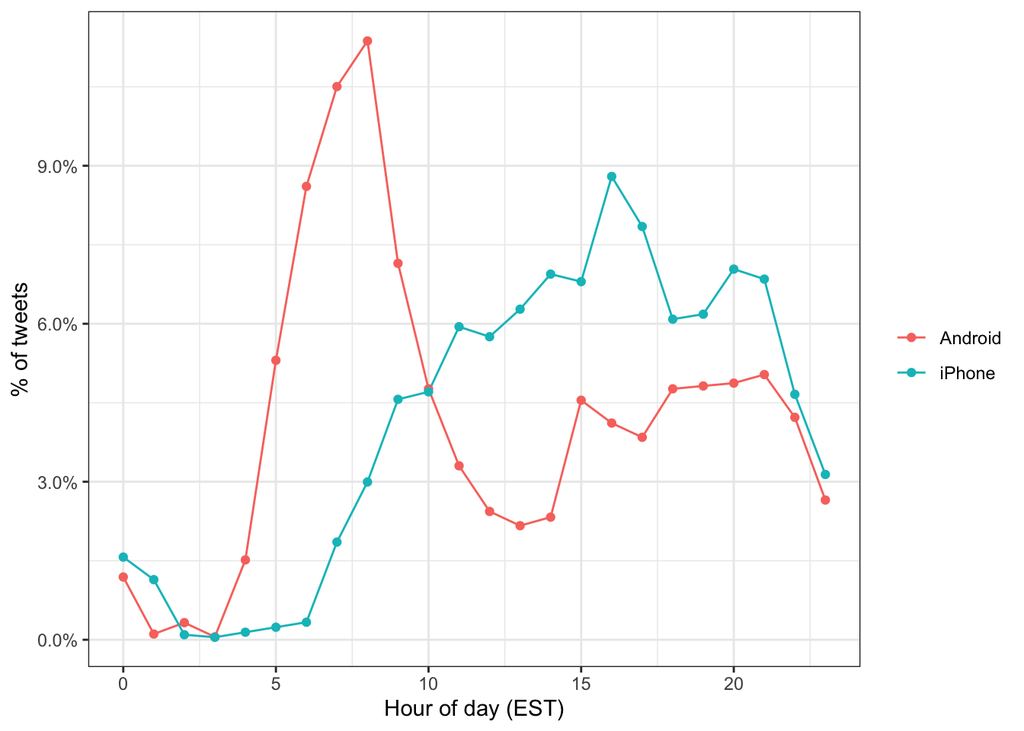

```r
ds_theme_set()
campaign_tweets %>%
  mutate(hour = hour(with_tz(created_at, "EST"))) %>%
  count(source, hour) %>%
  group_by(source) %>%
  mutate(percent = n / sum(n)) %>%
  ungroup %>%
  ggplot(aes(hour, percent, color = source)) +
  geom_line() +
  geom_point() +
  scale_y_continuous(labels = percent_format()) +
  labs(x = "Hour of day (EST)",
       y = "% of tweets",
       color = "")
```

We notice a big peak for the Android in early hours of the morning, between 6 and 8 AM. There seems to be a clear different in these patterns. We will therefore assume that two different entities are using these two devices. Now we will study how their tweets differ. To do this we introduce the tidytext package.

The tidytext package helps us convert free from text into a tidy table. Having the data in this format greatly facilitates data visualization and applying statistical techniques.

```r
if(!require(tidytext)) install.packages("tidytext")
library(tidytext)
```

Now let’s look at a quick example with a tweet number 3008.

```r
i <- 3008
campaign_tweets$text[i]
```

```
## [1] "Great to be back in Iowa! #TBT with @JerryJrFalwell joining me in Davenport- this past winter. #MAGA https://t.co/A5IF0QHnic"
```

```r
campaign_tweets[i,] %>%
  unnest_tokens(word, text) %>%
  select(word)
```

```
##                   word
## 3008             great
## 3008.1              to
## 3008.2              be
## 3008.3            back
## 3008.4              in
## 3008.5            iowa
## 3008.6             tbt
## 3008.7            with
## 3008.8  jerryjrfalwell
## 3008.9         joining
## 3008.10             me
## 3008.11             in
## 3008.12      davenport
## 3008.13           this
## 3008.14           past
## 3008.15         winter
## 3008.16           maga
## 3008.17          https
## 3008.18           t.co
## 3008.19     a5if0qhnic
```

Note that the function tries to convert tokens into words and strips characters important to twitter such as # and @. A token in twitter is not the same as in regular English. For this reason, instead of using the default token, words, we define a regex that captures twitter character. The pattern appears complex but all we are defining is a patter that starts with @, # or neither and is followed by any combination of letters or digits.

```r
pattern <- "([^A-Za-z\\d#@']|'(?![A-Za-z\\d#@]))"
```

We can now use the unnest_tokens() function with the regex option and appropriately extract the hashtags and mentions.

```r
campaign_tweets[i,] %>%
  mutate(text = str_replace_all(text, "https://t.co/[A-Za-z\\d]+|&amp;", ""))  %>%
  unnest_tokens(word, text, token = "regex", pattern = pattern) %>%
  select(word)
```

```
##               word
## 1            great
## 2               to
## 3               be
## 4             back
## 5               in
## 6             iowa
## 7             #tbt
## 8             with
## 9  @jerryjrfalwell
## 10         joining
## 11              me
## 12              in
## 13       davenport
## 14            this
## 15            past
## 16          winter
## 17           #maga
```

Now we are ready to extract the words for all our tweets.

```r
tweet_words <- campaign_tweets %>%
  mutate(text = str_replace_all(text, "https://t.co/[A-Za-z\\d]+|&amp;", ""))  %>%
  unnest_tokens(word, text, token = "regex", pattern = pattern)
```

And we can now answer questions such as “what are the most commonly used words?”

```r
tweet_words %>%
  count(word) %>%
  arrange(desc(n))
```

```
##                               word    n
## 1                              the 2335
## 2                               to 1413
## 3                              and 1246
## 4                                a 1210
## 5                               in 1189
## 6                                i 1161
## 7                              you 1000
## 8                               of  983
## 9                               is  944
## 10                              on  880
## 11                            will  845
## 12                             for  738
## 13                           thank  713
## 14                              be  670
```

[output cut: 6197 more lines]

It is not surprising that these are the top words. The top words are not informative. The tidytext package has database of these commonly used words, referred to as stop words, in text mining.

```r
stop_words
```

```
## # A tibble: 1,149 x 2
##    word        lexicon
##    <chr>       <chr>
##  1 a           SMART
##  2 a's         SMART
##  3 able        SMART
##  4 about       SMART
##  5 above       SMART
##  6 according   SMART
##  7 accordingly SMART
##  8 across      SMART
##  9 actually    SMART
## 10 after       SMART
## # … with 1,139 more rows
```

If we filter out rows representing stop words with filter(!word %in% stop_words$word).

```r
tweet_words <- campaign_tweets %>%
  mutate(text = str_replace_all(text, "https://t.co/[A-Za-z\\d]+|&amp;", ""))  %>%
  unnest_tokens(word, text, token = "regex", pattern = pattern) %>%
  filter(!word %in% stop_words$word )
```

We end up with a much more informative set of top 10 tweeted words.

```r
tweet_words %>%
  count(word) %>%
  top_n(10, n) %>%
  mutate(word = reorder(word, n)) %>%
  arrange(desc(n))
```

```
##                      word   n
## 1              #trump2016 415
## 2                 hillary 407
## 3                  people 303
## 4  #makeamericagreatagain 296
## 5                 america 254
## 6                 clinton 239
## 7                    poll 220
## 8                 crooked 206
## 9                   trump 199
## 10                   cruz 162
```

```r
tweet_words <- campaign_tweets %>%
  mutate(text = str_replace_all(text, "https://t.co/[A-Za-z\\d]+|&amp;", ""))  %>%
  unnest_tokens(word, text, token = "regex", pattern = pattern) %>%
  filter(!word %in% stop_words$word &
           !str_detect(word, "^\\d+$")) %>%
  mutate(word = str_replace(word, "^'", ""))
```

Now that we have all our words in a table, along with information about what device was used to compose the tweet they came from, we can start exploring which words are more common when comparing Android to iPhone.

For each word we want to know if it is more likely to come from an Android tweet or an iPhone tweet. We previously introduced the odds ratio, a summary statistic useful for quantifying these differences. For each device and a given word, let’s call it y, we compute the odds or the ratio between the proportion of words that are y and not y and compute the ratio of those odds. Here we will have many proportions that are 0 so we use the 0.5 correction.

```r
android_iphone_or <- tweet_words %>%
  count(word, source) %>%
  spread(source, n, fill = 0) %>%
  mutate(or = (Android + 0.5) / (sum(Android) - Android + 0.5) /
           ( (iPhone + 0.5) / (sum(iPhone) - iPhone + 0.5)))
android_iphone_or %>% arrange(desc(or))
```

```
##                               word Android iPhone           or
## 1                            mails      22      0 39.292266329
## 2                             poor      13      0 23.561944804
## 3                           poorly      12      0 21.815236289
## 4                         @cbsnews      11      0 20.068748617
## 5                           bosses      11      0 20.068748617
## 6                        turnberry      11      0 20.068748617
## 7                            angry      10      0 18.322481747
## 8                            write      10      0 18.322481747
## 9                           brexit       9      0 16.576435637
## 10                          defend       9      0 16.576435637
## 11                           funny       9      0 16.576435637
## 12                         playing       9      0 16.576435637
## 13                            pols       9      0 16.576435637
## 14                         sources       9      0 16.576435637
```

[output cut: 5495 more lines]

```r
android_iphone_or %>% arrange(or)
```

```
##                               word Android iPhone           or
## 1           #makeamericagreatagain       0    296  0.001438868
## 2                    #americafirst       0     71  0.006066172
## 3                   #draintheswamp       0     63  0.006834394
## 4                       #trump2016       3    412  0.007178869
## 5                       #votetrump       0     56  0.007685046
## 6                             join       1    157  0.008210326
## 7                       #imwithyou       0     51  0.008434234
## 8                  #crookedhillary       0     30  0.014263160
## 9                            #fitn       0     30  0.014263160
## 10                      #gopdebate       0     30  0.014263160
## 11                   #trumppence16       0     28  0.015266300
## 12                             7pm       0     25  0.017066051
## 13                 #bigleaguetruth       0     22  0.019345736
## 14                       #iacaucus       0     21  0.020247007
```

[output cut: 5495 more lines]

Given that several of these words are overall low frequency words we can impose a filter based on the total frequency like this.

```r
android_iphone_or %>% filter(Android+iPhone > 100) %>%
  arrange(desc(or))
```

```
##                      word Android iPhone          or
## 1                    @cnn     104     18 4.951435395
## 2                     bad     104     26 3.454656330
## 3                 crooked     157     49 2.792224365
## 4                     ted      85     28 2.624630823
## 5             interviewed      76     25 2.623702669
## 6                   media      77     26 2.557674284
## 7                    cruz     116     46 2.193350283
## 8                 hillary     290    119 2.140614127
## 9                     win      74     30 2.135192446
## 10              president      84     35 2.081263102
## 11                 debate      80     35 1.982238202
## 12               @foxnews      77     37 1.805980003
## 13                 people     195    109 1.563734838
## 14                country      67     38 1.531011257
```

[output cut: 16 more lines]

```r
android_iphone_or %>% filter(Android+iPhone > 100) %>%
  arrange(or)
```

```
##                      word Android iPhone          or
## 1  #makeamericagreatagain       0    296 0.001438868
## 2              #trump2016       3    412 0.007178869
## 3                    join       1    157 0.008210326
## 4                tomorrow      25    101 0.217801814
## 5                    vote      46     67 0.599501589
## 6                 america     114    141 0.703427318
## 7                 tonight      71     84 0.736615892
## 8                    iowa      62     65 0.831349391
## 9                    poll     117    103 0.989821637
## 10                  trump     112     92 1.060915059
## 11                clinton     136    108 1.097815307
## 12                  enjoy      69     51 1.177491166
## 13                  crowd      61     43 1.233667515
## 14                amazing      66     42 1.365885450
```

[output cut: 16 more lines]

We already see somewhat of a pattern in the types of words that are being tweeted more in one device versus the other. However, we are not interested in specific words but rather in the tone. Vaziri’s assertion is that the Android tweets are more hyperbolic. So how can we check this with data? Hyperbolic is a hard sentiment to extract from words as it relies on interpreting phrases.

However, words can be associated to more basic sentiment such as as anger, fear, joy and surprise. In the next section we demonstrate basic sentiment analysis. In sentiment analysis we assign a word to one or more “sentiment”. Although this approach will miss context dependent sentiments, such as sarcasm, when performed on large numbers of words, summaries can provide insights. The first step in sentiment analysis is to assign a sentiment to each word. The tidytext package includes several maps or lexicons in the object sentiments.

```r
sentiments
```

```
## # A tibble: 6,786 x 2
##    word        sentiment
##    <chr>       <chr>
##  1 2-faces     negative
##  2 abnormal    negative
##  3 abolish     negative
##  4 abominable  negative
##  5 abominably  negative
##  6 abominate   negative
##  7 abomination negative
##  8 abort       negative
##  9 aborted     negative
## 10 aborts      negative
## # … with 6,776 more rows
```

There are several lexicons in the tidytext package that give different sentiments. For example, the bing lexicon divides words into positive and negative. We can see this using the tidytext function get_sentiments().

```r
get_sentiments("bing")
```

[output not shown]

The AFINN lexicon assigns a score between -5 and 5, with -5 the most negative and 5 the most positive.

```r
get_sentiments("afinn")
```

[output not shown]

The loughran and nrc lexicons provide several different sentiments.

```r
get_sentiments("loughran") %>% count(sentiment)
```

[output not shown]

For the analysis here we are interested in exploring the different sentiments of each tweet, so we will use the nrc lexicon.

```r
get_sentiments("nrc") %>% count(sentiment)
```

```
## # A tibble: 10 x 2
##    sentiment        n
##    <chr>        <int>
##  1 anger         1247
##  2 anticipation   839
##  3 disgust       1058
##  4 fear          1476
##  5 joy            689
##  6 negative      3324
##  7 positive      2312
##  8 sadness       1191
##  9 surprise       534
## 10 trust         1231
```

```r
nrc <- get_sentiments("nrc") %>%
  select(word, sentiment)
```

We can combine the words and sentiments using inner_join(), which will only keep words associated with a sentiment. Here are 10 random words extracted from the tweets.

```r
tweet_words %>% inner_join(nrc, by = "word") %>%
  select(source, word, sentiment) %>% sample_n(10)
```

```
##     source        word sentiment
## 1  Android  compliment  positive
## 2   iPhone        join  positive
## 3   iPhone      manage     trust
## 4  Android       worse  negative
## 5  Android       level     trust
## 6   iPhone        vote  positive
## 7   iPhone       watch      fear
## 8   iPhone  university  positive
## 9   iPhone coincidence  surprise
## 10  iPhone magnificent       joy
```

Now we are ready to perform a quantitative analysis comparing Android and iPhone by comparing the sentiments of the tweets posted from each device. Here we could perform a tweet by tweet analysis, assigning a sentiment to each tweet. However, this somewhat complex since each tweet will have several sentiments attached to it, one for each word appearing in the lexicon. For illustrative purposes, we will perform a much simpler analysis: we will count and compare the frequencies of each sentiment appears for each device.

```r
sentiment_counts <- tweet_words %>%
  left_join(nrc, by = "word") %>%
  count(source, sentiment) %>%
  spread(source, n) %>%
  mutate(sentiment = replace_na(sentiment, replace = "none"))
sentiment_counts
```

```
##       sentiment Android iPhone
## 1         anger     965    527
## 2  anticipation     915    710
## 3       disgust     641    318
## 4          fear     802    486
## 5           joy     698    540
## 6      negative    1668    935
## 7      positive    1834   1497
## 8       sadness     907    514
## 9      surprise     530    365
## 10        trust    1253   1010
## 11         none   11523  10739
```

Because more words were used on the Android than on the phone.

```r
tweet_words %>% group_by(source) %>% summarize(n = n())
```

```
## # A tibble: 2 x 2
##   source      n
##   <chr>   <int>
## 1 Android 15829
## 2 iPhone  13802
```

For each sentiment we can compute the odds of being in the device: proportion of words with sentiment versus proportion of words without and then compute the odds ratio comparing the two device.

```r
sentiment_counts %>%
  mutate(Android = Android / (sum(Android) - Android) ,
         iPhone = iPhone / (sum(iPhone) - iPhone),
         or = Android/iPhone) %>%
  arrange(desc(or))
```

```
##       sentiment    Android     iPhone        or
## 1       disgust 0.03038635 0.01835710 1.6552915
## 2         anger 0.04645901 0.03079350 1.5087275
## 3      negative 0.08311740 0.05596792 1.4850902
## 4       sadness 0.04354506 0.03001109 1.4509654
## 5          fear 0.03831088 0.02832993 1.3523111
## 6      surprise 0.02499293 0.02112758 1.1829529
## 7           joy 0.03317806 0.03157710 1.0507000
## 8  anticipation 0.04394602 0.04193491 1.0479577
## 9         trust 0.06117268 0.06072996 1.0072899
## 10     positive 0.09215154 0.09272795 0.9937839
## 11         none 1.12826789 1.55592582 0.7251425
```

So we do see some difference and the order is interesting: the largest three sentiments are disgust, anger, and negative! But are they statistically significant? How does this compare if we are just assigning sentiments at random?

To answer that question we can compute, for each sentiment, an odds ratio and confidence interval. We will add the two values we need to form a two-by-two table and the odds ratio.

```r
library(broom)
log_or <- sentiment_counts %>%
  mutate( log_or = log( (Android / (sum(Android) - Android)) / (iPhone / (sum(iPhone) - iPhone))),
          se = sqrt( 1/Android + 1/(sum(Android) - Android) + 1/iPhone + 1/(sum(iPhone) - iPhone)),
          conf.low = log_or - qnorm(0.975)*se,
          conf.high = log_or + qnorm(0.975)*se) %>%
  arrange(desc(log_or))

log_or
```

```
##       sentiment Android iPhone       log_or         se    conf.low   conf.high
## 1       disgust     641    318  0.503977127 0.06935307  0.36804761  0.63990664
## 2         anger     965    527  0.411266612 0.05513963  0.30319493  0.51933829
## 3      negative    1668    935  0.395475483 0.04217497  0.31281405  0.47813691
## 4       sadness     907    514  0.372229104 0.05616457  0.26214858  0.48230963
## 5          fear     802    486  0.301815029 0.05839998  0.18735318  0.41627688
## 6      surprise     530    365  0.168013748 0.06878633  0.03319502  0.30283247
## 7           joy     698    540  0.049456578 0.05822822 -0.06466864  0.16358179
## 8  anticipation     915    710  0.046843264 0.05107288 -0.05325773  0.14694426
## 9         trust    1253   1010  0.007263495 0.04355609 -0.07810488  0.09263187
## 10     positive    1834   1497 -0.006235497 0.03640670 -0.07759131  0.06512032
## 11         none   11523  10739 -0.321387131 0.02055970 -0.36168341 -0.28109085
```

A graphical visualization shows some sentiments that are clearly overrepresented.

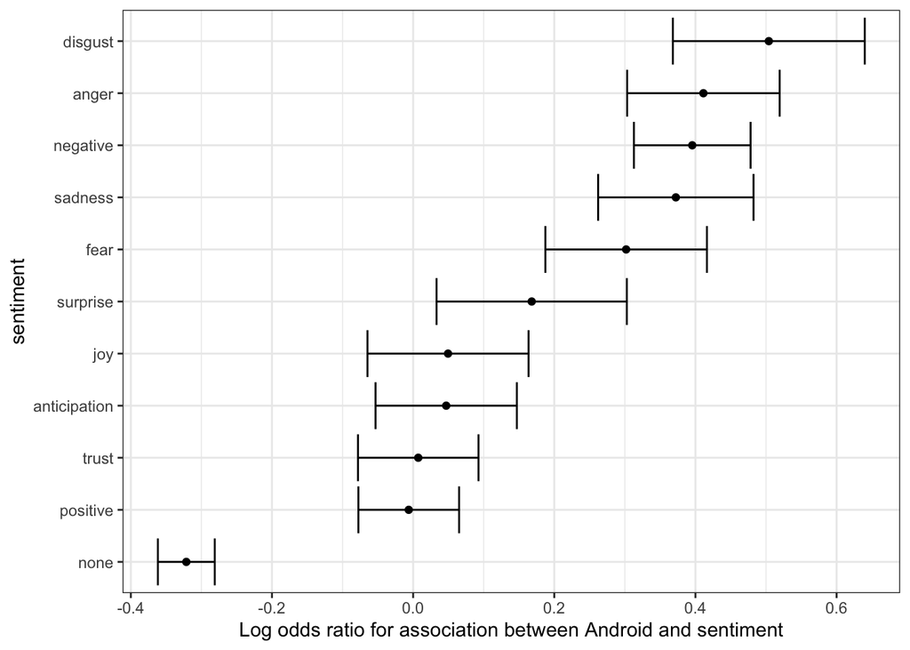

```r
log_or %>%
  mutate(sentiment = reorder(sentiment, log_or),) %>%
  ggplot(aes(x = sentiment, ymin = conf.low, ymax = conf.high)) +
  geom_errorbar() +
  geom_point(aes(sentiment, log_or)) +
  ylab("Log odds ratio for association between Android and sentiment") +
  coord_flip()
```

We see that the disgust, anger, negative sadness and fear sentiments are associated with the Android in a way that is hard to explain by chance alone. Words not associated to a sentiment were strongly associated with the iPhone source, which is in agreement with the original claim about hyperbolic tweets.

If we are interested in exploring which specific words are driving these differences, we can go back to our android_iphone_or object.

```r
android_iphone_or %>% inner_join(nrc) %>%
  filter(sentiment == "disgust" & Android + iPhone > 10) %>%
  arrange(desc(or))
```

```
##         word Android iPhone        or sentiment
## 1       mess      15      2 5.4104208   disgust
## 2    finally      12      2 4.3624150   disgust
## 3     unfair      12      2 4.3624150   disgust
## 4        bad     104     26 3.4546563   disgust
## 5        lie      13      3 3.3652605   disgust
## 6   terrible      31      8 3.2358005   disgust
## 7      lying       9      3 2.3675475   disgust
## 8      waste      12      5 1.9824849   disgust
## 9      phony      21      9 1.9746888   disgust
## 10   illegal      32     14 1.9563386   disgust
## 11     nasty      14      6 1.9459902   disgust
## 12  pathetic      11      5 1.8237708   disgust
## 13  horrible      14      7 1.6864026   disgust
## 14  disaster      21     11 1.6310282   disgust
## 15   winning      14      9 1.3311774   disgust
## 16      liar       6      5 1.0305012   disgust
## 17 dishonest      37     32 1.0061129   disgust
## 18      john      24     21 0.9936098   disgust
## 19     dying       6      6 0.8718994   disgust
## 20 terrorism       9      9 0.8718751   disgust
```

We can make a graph.

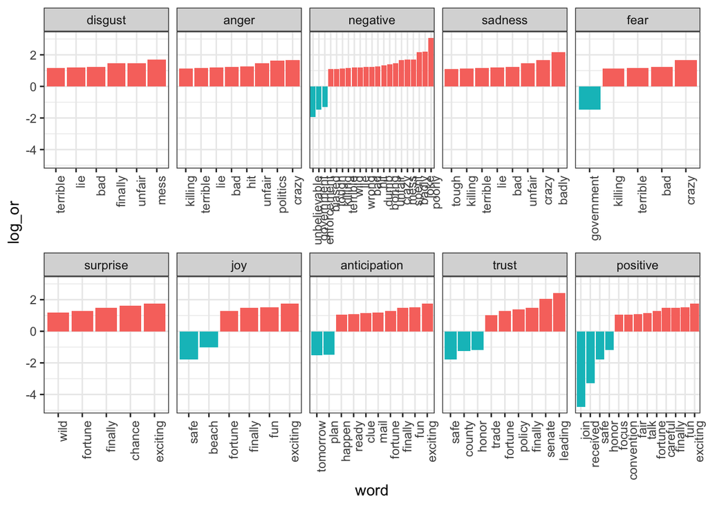

```r
android_iphone_or %>% inner_join(nrc, by = "word") %>%
  mutate(sentiment = factor(sentiment, levels = log_or$sentiment)) %>%
  mutate(log_or = log(or)) %>%
  filter(Android + iPhone > 10 & abs(log_or)>1) %>%
  mutate(word = reorder(word, log_or)) %>%
  ggplot(aes(word, log_or, fill = log_or < 0)) +
  facet_wrap(~sentiment, scales = "free_x", nrow = 2) +
  geom_bar(stat="identity", show.legend = FALSE) +
  theme(axis.text.x = element_text(angle = 90, hjust = 1))
```